# Understanding Bayesian Estimation

# Introduction

In this notebook, we will work through the Bayesian estimation example from Section 11.4 of the textbook.

**Problem setup:** We want to infer the effectiveness of a new pain-relieving drug. We know that 64 out of 100 patients responded positively to the drug. Knowing this, what can we infer about the true effectiveness of the drug?

To do this, will estimate the effectiveness of the pain drug by computing a **posterior distribution** over the parameter `p_respond` (the proportion of people who respond positively to the drug).

## Load Libraries

```r
library(tidyverse)
library(patchwork)  # for combining plots
```

# The Problem Setup

```r
# Our observed data
n_patients <- 100
n_responders <- 64

# Parameter space: all possible values of p_respond we will consider
# (In reality this is continuous, but we use discrete values for simplicity)
p_respond_values <- seq(0.01, 0.99, by = 0.01)
n_values <- length(p_respond_values)
```

# Step 1: The Prior Distribution

Before seeing any data, what do we believe about `p_respond` i.e., P(p_respond)?

Since we have no prior information about this drug, we’ll use a **uniform prior** - all values are equally likely. In order to simplify the example, we will only look at a subset of 99 possible values of effectiveness (from .01 to .99, in steps of .01). Therefore, each possible value has a prior probability of 1/99.

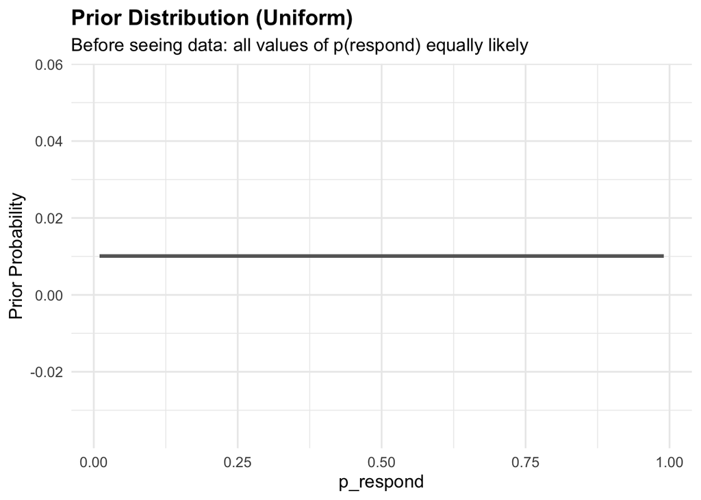

```r
# Uniform prior: each value has probability 1/99
prior <- rep(1/n_values, n_values)

# Create dataframe for plotting
prior_df <- tibble(
  p_respond = p_respond_values,
  probability = prior
)

# Visualize
ggplot(prior_df, aes(x = p_respond, y = probability)) +
  geom_line(linewidth = 1.2, color = "gray40") +
  labs(
    title = "Prior Distribution (Uniform)",
    subtitle = "Before seeing data: all values of p(respond) equally likely",
    x = "p_respond",
    y = "Prior Probability"
  ) +
  theme_minimal(base_size = 13) +
  theme(plot.title = element_text(face = "bold"))
```

**Note:** This flat line means we have no reason to favor any particular value of `p_respond` before seeing the data.

# Step 2: The Likelihood Function

For each possible value of `p_respond`, we ask: **“How likely would we be to observe 64 responders out of 100?”**

We compute this using the **binomial distribution** because:

- Each patient responds independently
- Each has binary outcome (respond or not)
- Each has the same probability `p_respond`

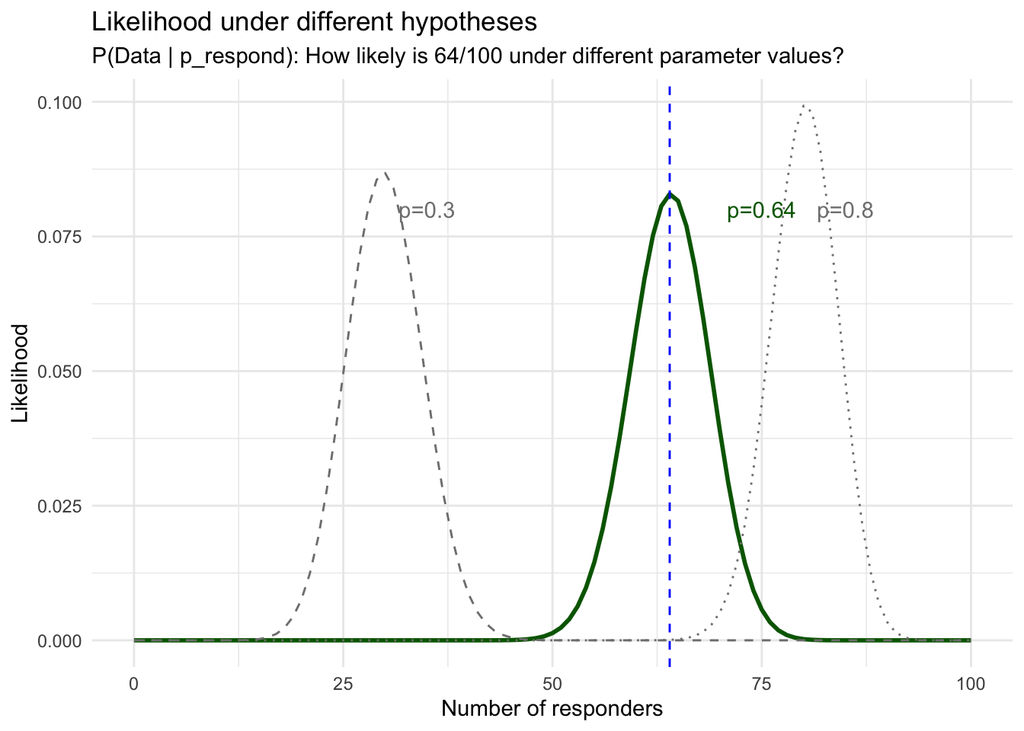

```r
# Create likelihood distributions for several p_respond values
likelihood_df <- tibble(
  n_responders = 0:100
) %>%
  mutate(
    p_respond = n_responders / 100,
    likelihood_0.3 = dbinom(n_responders, 100, 0.3),
    likelihood_0.64 = dbinom(n_responders, 100, 0.64),
    likelihood_0.8 = dbinom(n_responders, 100, 0.8)
  )

# Plot
ggplot(likelihood_df, aes(n_responders, likelihood_0.64)) +
  geom_line(linewidth = 1, color = 'darkgreen') +
  geom_line(aes(y = likelihood_0.3), linetype = 'dashed', color = 'gray50') +
  geom_line(aes(y = likelihood_0.8), linetype = 'dotted', color = 'gray50') +
  geom_vline(xintercept = 64, color = 'blue', linetype = 'dashed') +
  annotate("text", x = 75, y = 0.08, label = "p=0.64", color = 'darkgreen') +
  annotate("text", x = 35, y = 0.08, label = "p=0.3", color = 'gray50') +
  annotate("text", x = 85, y = 0.08, label = "p=0.8", color = 'gray50') +
  labs(
    title = 'Likelihood under different hypotheses',
    subtitle = "P(Data | p_respond): How likely is 64/100 under different parameter values?",
    x = 'Number of responders',
    y = 'Likelihood'
  ) +
  theme_minimal()
```

**Note:**

- The likelihood peaks near 0.64 (the observed proportion)
- Values far from 0.64 make the observed data very unlikely

# Step 3: The denominator i.e., marginal likelihood

The denominator i.e., the marginal likelihood is: **P(Data) = Σ P(Data | p_respond) × P(p_respond)**

This sums over all possible parameter values and serves as a **normalizing constant** to ensure our posterior is a valid probability distribution.

```r
likelihood <- dbinom(n_responders, size = n_patients, prob = p_respond_values)
# Compute marginal likelihood
marginal_likelihood <- sum(likelihood * prior)

cat("P(Data):", round(marginal_likelihood, 6), "\n\n")
```

```
## P(Data): 0.010001
```

# Step 4: The Posterior Distribution

Now we apply **Bayes’ Theorem**:

$$P(p_{respond} | Data) = \frac{P(Data |
p_{respond}) \times P(p_{respond})}{P(Data)}$$

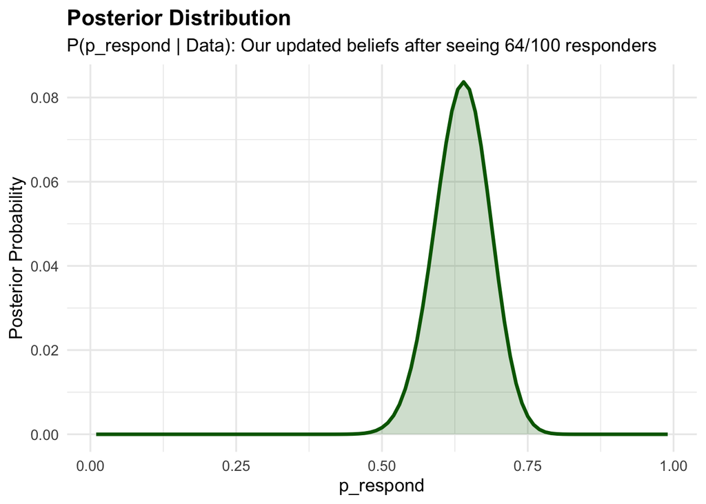

```r
# Compute posterior using Bayes' theorem
posterior <- (likelihood * prior) / marginal_likelihood

# Create dataframe
posterior_df <- tibble(
  p_respond = p_respond_values,
  probability = posterior
)

# Visualize
ggplot(posterior_df, aes(x = p_respond, y = probability)) +
  geom_line(linewidth = 1.2, color = "darkgreen") +
  geom_area(fill = "darkgreen", alpha = 0.2) +
  labs(
    title = "Posterior Distribution",
    subtitle = "P(p_respond | Data): Our updated beliefs after seeing 64/100 responders",
    x = "p_respond",
    y = "Posterior Probability"
  ) +
  theme_minimal(base_size = 13) +
  theme(plot.title = element_text(face = "bold"))
```

This distribution shows which values of `p_respond` are most plausible given our data. The peak is around 0.64. This shouldn’t be surprising because we started with a uniform prior!

# Maximum A Posteriori (MAP) Estimate

Given our data we would like to obtain an estimate of p_respond for our sample. One way to do this is to find the value of p_respond for which the posterior probability is the highest, which we refer to as the *maximum a posteriori* (MAP) estimate.

The **MAP estimate** is simply the value of `p_respond` with the highest posterior probability.

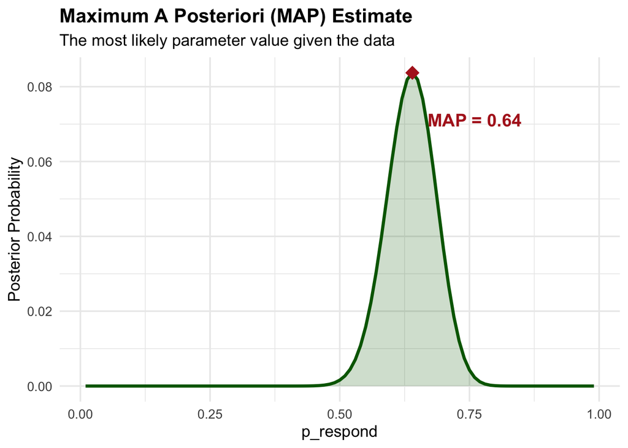

```r
# Find MAP
MAP_idx <- which.max(posterior)
MAP_estimate <- p_respond_values[MAP_idx]

# Visualize
ggplot(posterior_df, aes(x = p_respond, y = probability)) +
  geom_line(linewidth = 1.2, color = "darkgreen") +
  geom_area(fill = "darkgreen", alpha = 0.2) +
  geom_point(data = tibble(p_respond = MAP_estimate,
                           probability = max(posterior)),
             size = 5, shape = 18, color = "firebrick") +
  annotate("text", x = MAP_estimate + 0.12, y = max(posterior) * 0.85,
           label = paste("MAP =", MAP_estimate),
           color = "firebrick", size = 5, fontface = "bold") +
  labs(
    title = "Maximum A Posteriori (MAP) Estimate",
    subtitle = "The most likely parameter value given the data",
    x = "p_respond",
    y = "Posterior Probability"
  ) +
  theme_minimal(base_size = 13) +
  theme(plot.title = element_text(face = "bold"))
```

# Step 7: Credible Intervals

A **95% credible interval** contains 95% of the posterior probability.

**Interpretation (much better than confidence intervals!):** *“There is a 95% probability that the true `p_respond` falls in this interval.”*

```r
# Compute 95% credible interval
# First compute cumulative probabilities
cumulative_prob <- cumsum(posterior)

# Find boundaries
lower_idx <- which(cumulative_prob >= 0.025)[1]  # 2.5th percentile
upper_idx <- which(cumulative_prob >= 0.975)[1]  # 97.5th percentile

credible_interval <- c(
  lower = p_respond_values[lower_idx],
  upper = p_respond_values[upper_idx]
)


cat("95% Credible Interval: [", credible_interval["lower"], ", ",
    credible_interval["upper"], "]\n\n", sep = "")
```

```
## 95% Credible Interval: [0.54, 0.73]
```

```r
cat("We are 95% confident the true p_respond is between",
    credible_interval["lower"], "and", credible_interval["upper"], "\n")
```

```
## We are 95% confident the true p_respond is between 0.54 and 0.73
```

# Effect of Different Priors

What if we had **prior beliefs** about the drug’s effectiveness? Let’s compare three scenarios:

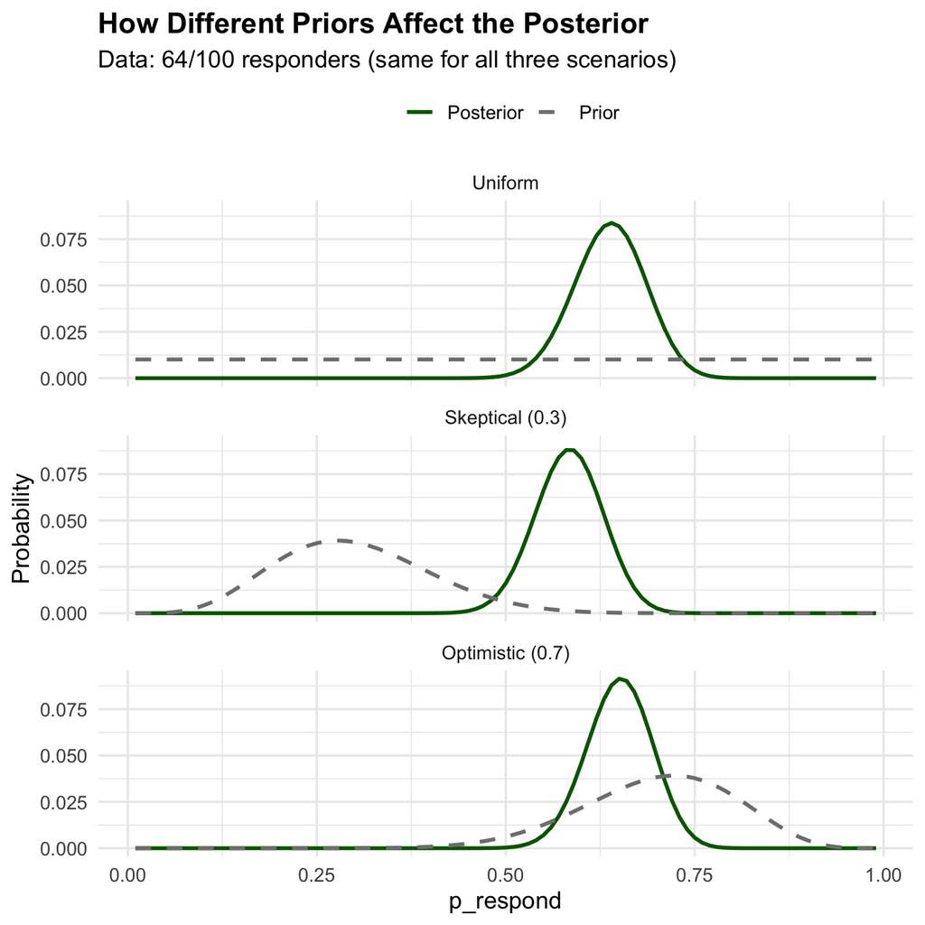

```r
# Define different priors

# 1. Uniform (what we used above)
prior_uniform <- rep(1/n_values, n_values)

# 2. Skeptical prior: previous study suggested p = 0.3
prior_skeptical <- dbeta(p_respond_values, shape1 = 6, shape2 = 14)
prior_skeptical <- prior_skeptical / sum(prior_skeptical)

# 3. Optimistic prior: previous study suggested p = 0.7
prior_optimistic <- dbeta(p_respond_values, shape1 = 14, shape2 = 6)
prior_optimistic <- prior_optimistic / sum(prior_optimistic)

# Compute posteriors for each
posterior_uniform <- (likelihood * prior_uniform) / sum(likelihood * prior_uniform)
posterior_skeptical <- (likelihood * prior_skeptical) / sum(likelihood * prior_skeptical)
posterior_optimistic <- (likelihood * prior_optimistic) / sum(likelihood * prior_optimistic)

# Combine for plotting
comparison_priors_df <- tibble(
  p_respond = rep(p_respond_values, 6),
  probability = c(prior_uniform, prior_skeptical, prior_optimistic,
                  posterior_uniform, posterior_skeptical, posterior_optimistic),
  type = rep(c("Prior", "Posterior"), each = n_values * 3),
  scenario = rep(rep(c("Uniform", "Skeptical (0.3)", "Optimistic (0.7)"),
                     each = n_values), 2)
) %>%
  mutate(scenario = factor(scenario,
                          levels = c("Uniform", "Skeptical (0.3)", "Optimistic (0.7)")))

# Plot
ggplot(comparison_priors_df, aes(x = p_respond, y = probability,
                                  color = type, linetype = type)) +
  geom_line(linewidth = 1) +
  facet_wrap(~scenario, ncol = 1) +
  scale_color_manual(values = c("Prior" = "gray50", "Posterior" = "darkgreen")) +
  scale_linetype_manual(values = c("Prior" = "dashed", "Posterior" = "solid")) +
  labs(
    title = "How Different Priors Affect the Posterior",
    subtitle = "Data: 64/100 responders (same for all three scenarios)",
    x = "p_respond",
    y = "Probability",
    color = "",
    linetype = ""
  ) +
  theme_minimal(base_size = 13) +
  theme(legend.position = "top",
        plot.title = element_text(face = "bold"))
```

# Summary

**What we learned:**

1. **Bayesian estimation** gives us a full posterior distribution, not just a point estimate
2. **Bayes’ theorem** combines prior beliefs with data via the likelihood
3. **MAP estimate** is the peak of the posterior
4. **Credible intervals** have intuitive probabilistic interpretation
5. **Priors matter** - but with enough data, the likelihood dominates

**Key advantages over frequentist methods:**

- Direct probability statements about parameters
- Interpretable intervals
- Natural way to incorporate prior knowledge
- Sequential updating (yesterday’s posterior are today’s prior)